# Day 4: carbonate

Welcome back for the 4th day of the [#packagecalendar](https://twitter.com/hashtag/packagecalendar), today we will revisit [Jonathan Sidi](https://twitter.com/yoniceedee)’s creations by looking at carbonate. The package is a nice way of interacting with [carbon.js](https://carbon.now.sh/about).

the package is available from CRAN and can be downloaded with

```r
install.packages("carbonate")
```

The **carbonate** package uses the R6 classes which is why the syntax might look a little different then what you are used to.

```r
library(carbonate)
```

The default behavior is to take the code you have in your clipboard. Here we create an object `x` with the code used to display yesterday’s secret.

```r
x <- carbon$new()
```

We can take a look at the code with

```r
x$code
```

```
##  [1] "library(tidyverse)"
##  [2] "symbols <- c('.', '~', \"'\", 'O', \"'\", '~', '.')"
##  [3] "layer_size <- seq(3, 45, by = 4)"
##  [4] ""
##  [5] "things <- rep(symbols, length.out = sum(layer_size))"
##  [6] ""
##  [7] "rows <- split(things, rep(seq_along(layer_size), times = layer_size)) %>%"
##  [8] "  sapply(paste0, collapse = \"\")"
##  [9] ""
## [10] "details(summary = \"Open for a special presents\","
## [11] "        tibble(x = 0, "
## [12] "               y = -as.numeric(names(rows)),"
## [13] "               labels = rows) %>%"
## [14] "          ggplot(aes(x, y, label = labels)) +"
## [15] "          geom_text(size = 10) +"
## [16] "          theme_void()"
## [17] ")"
```

If you want the carbon output you have two ways to go

## Browse

calling the `browse()` method takes you to [carbon.now.sh](https://carbon.now.sh/) with your code and configurations already there. From there you can play more with the configurations or simply press **export** to download your image.

```r
x$browse()
```

## RSelenium

If you have [RSelenium](https://ropensci.github.io/RSelenium/) installed you can create the image without leaving R. You just set the download path and run the `carbonate()` method.

```r
x$download_path <- file.path("~/Desktop/")
x$carbonate(file = 'myfile.png')
```

No matter what you choose you will end up with something like this:

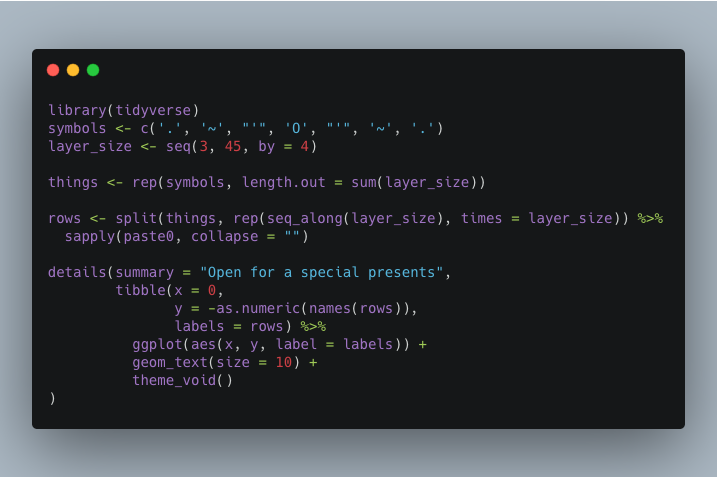

There is a ton of [options](https://yonicd.github.io/carbonate/#manipulate-carbon-object) to manipulate. So go wild and make it your own! See you next time!